# Multiple Model Analysis

## Introduction

Statistical Analysis project with the goal of comparing multiple linear models for the Balance variable in credit data.

We will examing the following models to try and apply to future credit card data to estimate balance numbers.

1. Ordinary Least Squared
2. Lasso
3. Ridge
4. Principal Component Regression
5. Partial Least Squared Regression

## Data

We have a data set containing variables that relate to credit.

**4 Qualitative Variables** 1. Gender 2. Student 3. Married Ethnicity

**7 Quantitative Variables** 1. Income 2. Limit 3. Rating 4. Cards 5. Age 6. Education 7. Balance

We trained ou models with a set of 300 points and tested on 100 points taken randomly from the original Credit.csv data

## Examining the Credits data

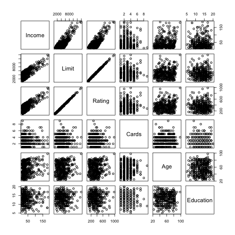

Scatters

## Correlation

### Matrix

```
##                Income       Limit      Rating       Cards         Age
## Income     1.00000000  0.79208834  0.79137763 -0.01827261 0.175338403
## Limit      0.79208834  1.00000000  0.99687974  0.01023133 0.100887922
## Rating     0.79137763  0.99687974  1.00000000  0.05323903 0.103164996
## Cards     -0.01827261  0.01023133  0.05323903  1.00000000 0.042948288
## Age        0.17533840  0.10088792  0.10316500  0.04294829 1.000000000
## Education -0.02769198 -0.02354853 -0.03013563 -0.05108422 0.003619285
##              Education
## Income    -0.027691982
## Limit     -0.023548534
## Rating    -0.030135627
## Cards     -0.051084217
## Age        0.003619285
## Education  1.000000000
```

## Comparing Errors for PCR and PLSR

PCR CV Errors

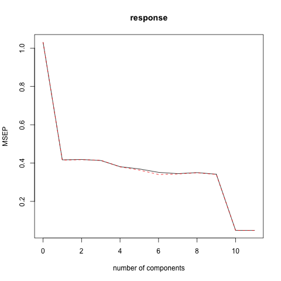

…

PLSR CV ERrors

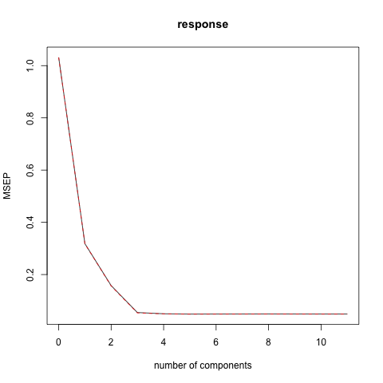

## Coefficients of the Models

### Our predictors

Compare - Coefficients

|  | Variables | OLS | Ridge | Lasso | PCR | PLSR |
| --- | --- | --- | --- | --- | --- | --- |
| 1 | Intercept | -0.003 | 0.000 | 0.000 | 0.000 | 0.000 |
| 2 | Income | -0.605 | -0.574 | -0.540 | -0.605 | -0.605 |
| 3 | Limit | 1.067 | 0.718 | 0.815 | 1.067 | 1.067 |
| 4 | Rating | 0.286 | 0.603 | 0.470 | 0.286 | 0.286 |
| 5 | Cards | 0.058 | 0.044 | 0.040 | 0.058 | 0.058 |
| 6 | Age | -0.013 | -0.016 | -0.005 | -0.013 | -0.013 |
| 7 | Education | -0.006 | -0.005 | 0.000 | -0.006 | -0.006 |
| 8 | GenderFemale | -0.015 | -0.013 | 0.000 | -0.015 | -0.015 |
| 9 | StudentYes | 0.282 | 0.276 | 0.266 | 0.282 | 0.282 |
| 10 | MarriedYes | -0.009 | -0.012 | 0.000 | -0.009 | -0.009 |
| 11 | EthnicityAsian | 0.011 | 0.010 | 0.000 | 0.011 | 0.011 |
| 12 | EthnicityCaucasian | 0.011 | 0.011 | 0.000 | 0.011 | 0.011 |

## Model MSE

Compare - MSE

|  | Model | MSE |
| --- | --- | --- |
| 1 | OLS | 0.047 |
| 2 | Ridge | 0.045 |
| 3 | Lasso | 0.047 |
| 4 | PCR | 0.047 |
| 5 | PLSR | 0.047 |

## Comparing Coeffecients

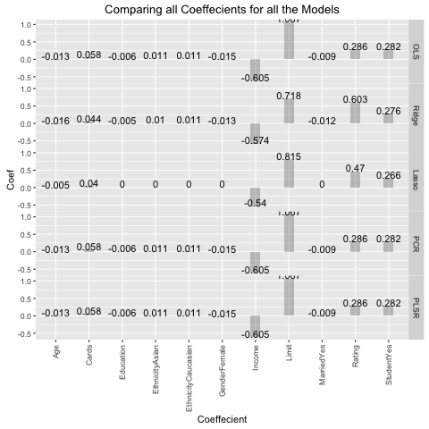

Coefficients for all Models

**The best predictor based on having the least error is Ridge**

## Takeaways:

**Best Model** The best model is the Ridge model because it has the lowest MSE for our data